# `R` crash course, eXtreme

Jongbin Jung

## Dependencies

- Please download and install
  - Latest version `R` (*free* – GPL – from https://www.r-project.org/)
  - Latest version of `Rstudio` (also *free* – [AGPL](http://www.gnu.org/licenses/agpl-3.0.txt) – from https://www.rstudio.com/)
- Alternatively, use cloud services such as [MatrixDS](http://matrixds.com) (http://matrixds.com)

## Using `Rstudio`

- Save/load scripts as text files named `*.R`
- Save/load environment as `.Rdata` file
- `Ctrl` + `L`: Clear console
- `Ctrl` + `#`: Focus on panel `#`
- `Ctrl` + `Enter`: Execute line/selection
- `Ctrl` + `Shift` + `A`: Auto-format selected code
- `Ctrl` + `Shift` + `C`: Comment/Uncomment selection
- `Ctrl` + `Shift` + `/`: Reflow comments
- Many more (if you’re willing to explore)

# `R` Basics

## Working Directory

- Working directory (`wd`) is where your `R` session will load/save files
- To see where your current working directory is, run

```r
getwd()
```

- To set the working directory to desired `path`, run

```r
setwd("path")
```

- Note that `~` is replaced with your `HOME` directory, e.g. `C:\Users\Username\Documents` in windows
- Use forward slashes (`/`), even on Windows!

```r
setwd("~/R")
```

- **Never** set the working directory to an absolute path in your `R` script
  - Even better, organize your scripts such that you never have to change the working directory
  - `setwd()` is best reserved for that time when you started `R` from the wrong directory

## Assignment

- Convention for assigning values to variables is an arrow(`<-`)[^1]
- Direction of arrow indicates direction of assignment

```r
A <- 12
A  # 12
A + 3 -> B
B  # 15
24 -> A
A  # 24
```

- The equal sign (`=`) also works, but only for assignment to the left, e.g.

```r
A = 12  # good
12 = A  # BAD
```

## Strings

- A `String` variable can be declared in either double quotes(`""`) or single quotes (`''`)

```r
s <- "This is a valid string"
s
```

```
## [1] "This is a valid string"
```

```r
s <- 'and so is this'
s
```

```
## [1] "and so is this"
```

## Vectors

### Creating vectors with `c()`

- Vectors are the building blocks of `R` — even a single variable is actually an “atomic” vector (vector of size 1)
- Vectors in `R` are created by *c*oncatenating a series of elements

```r
X <- c(1,2,3)
X  # vector of numbers (1, 2, 3)
```

```
## [1] 1 2 3
```

```r
Y <- c('this', 'that', 'those')
Y  # this is a vector of Strings
```

```
## [1] "this"  "that"  "those"
```

### Generate sequence with `seq()`

- Create a vector from a sequence with `seq(from, to, by=1)`

```r
seq(1, 10)
```

```
##  [1]  1  2  3  4  5  6  7  8  9 10
```

```r
seq(1, 10, 2)
```

```
## [1] 1 3 5 7 9
```

- Use short-hand `from:to` if you’re incrementing by one

```r
1:10
```

```
##  [1]  1  2  3  4  5  6  7  8  9 10
```

### Repeat values with `rep()`

- Use `rep()` to repeat values

```r
rep(13, 4)
```

```
## [1] 13 13 13 13
```

```r
rep('Yes!', 3)
```

```
## [1] "Yes!" "Yes!" "Yes!"
```

```r
rep(c('Sat.', 'Sun.'), 2)
```

```
## [1] "Sat." "Sun." "Sat." "Sun."
```

### Indexing

- Use square braces (`[]`) to index a vector (base 1)
  - Indexing out-of-bounds returns a special value called `NA`, *does NOT* fail

```r
X <- c(10, 11, 12, 13)
X[1]
```

```
## [1] 10
```

```r
X[4]
```

```
## [1] 13
```

```r
X[5]  # Does NOT fail; but returns NA
```

```
## [1] NA
```

- Negative indexing is used to exclude elements

```r
X[-1]
```

```
## [1] 11 12 13
```

- Index multiple objects by indexing with a vector

```r
ind <- c(2, 4)
X[ind]
```

```
## [1] 11 13
```

## Built-in functions

### Common functions

```r
mean(X)                # mean
sd(X)                  # standard deviation
var(X)                 # variance
max(X)                 # maximum
min(X)                 # minimum
median(X)              # median
sum(X)                 # sum
prod(X)                # product
quantile(X,probs=0.5)  # quantile for specified probs
length(X)              # length of the vector
range(X)               # range

log(X)   # element-wise log
exp(X)   # element-wise exponential
sqrt(X)  # element-wise square root
```

### Functions for strings

```r
# concatenate two (or more) strings
paste('one plus one equals', 1+1, '!')
```

```
## [1] "one plus one equals 2 !"
```

```r
# specify a separator
paste('one plus one', 1+1, sep='=')
```

```
## [1] "one plus one=2"
```

```r
# if you're into C-style formatting ...
sprintf('one plus one = %d', 1+1)
```

```
## [1] "one plus one = 2"
```

- Often, we want to concatenate strings with no spaces (e.g., when constructing filenames/paths at run-time)

```r
# short-hand for concatenation w/o spaces
filename = 'some_file_name.csv'
paste0('path/to/', filename)
```

```
## [1] "path/to/some_file_name.csv"
```

```r
# function specifically for constructing file paths
file.path('path', 'to', filename)
```

```
## [1] "path/to/some_file_name.csv"
```

### Generic Functions

- Some functions for exploring objects

```r
obj <- 1:100
head(obj, n=5)  # display first n rows of obj
```

```
## [1] 1 2 3 4 5
```

```r
tail(obj, n=5)  # display last n rows of obj
```

```
## [1]  96  97  98  99 100
```

```r
str(obj)  # display structure of obj
```

```
##  int [1:100] 1 2 3 4 5 6 7 8 9 10 ...
```

```r
summary(obj)  # display summary of obj
```

```
##    Min. 1st Qu.  Median    Mean 3rd Qu.    Max.
##     1.0    25.8    50.5    50.5    75.2   100.0
```

## Data frames

- Data frames are the primary representation of data in `R`
- You can think of a data frame as a two-dimensional *table* of data
- It helps your sanity to always think of data frames as a table where

```
Each column represents a variable/feature
Each row represents an observation/instance
```

- Conceptually, a data frame is also a collection of vectors, i.e., each column is a vector that belongs to the (parent) data frame

### Display Structure with `str()`

- Let’s start looking at the `txhousing` data frame
- The `str()` function is useful for exploring the overall structure of a data frame

```r
str(txhousing)
```

```
## Classes 'tbl_df', 'tbl' and 'data.frame':    8602 obs. of  9 variables:
##  $ city     : chr  "Abilene" "Abilene" "Abilene" "Abilene" ...
##  $ year     : int  2000 2000 2000 2000 2000 2000 2000 2000 2000 2000 ...
##  $ month    : int  1 2 3 4 5 6 7 8 9 10 ...
##  $ sales    : num  72 98 130 98 141 156 152 131 104 101 ...
##  $ volume   : num  5380000 6505000 9285000 9730000 10590000 ...
##  $ median   : num  71400 58700 58100 68600 67300 66900 73500 75000 64500 59300 ...
##  $ listings : num  701 746 784 785 794 780 742 765 771 764 ...
##  $ inventory: num  6.3 6.6 6.8 6.9 6.8 6.6 6.2 6.4 6.5 6.6 ...
##  $ date     : num  2000 2000 2000 2000 2000 ...
```

### `Factor`s

- Note that the city column should be a `factor` – a data frame representation of categorical variables
- Use `factor()` to force varaibles into factor variables

```r
txhousing$city <- factor(txhousing$city)
```

- The entries of a `factor` variable is defined by `levels`

```r
levels(txhousing$city)
```

## Packages

### Installing `R` Packages

- `R` has many (*MANY*) packages created by other users that implement state-of-the-art tools (e.g., data manipulation, statistical models)
- These packages can be downloaded from the Comprehensive R Archive Network (CRAN)
- This is as simple as running a single line of code:

```r
install.packages("package name")
```

- You will have to select one of many CRAN mirrors (copies across different servers) from which to download the package from
- For example, to install the `tidyverse` package, run

```r
install.packages("tidyverse")
```

- You only need to do this *once* for each machine

### Loading Packages

- Once you’ve installed a package on a machine, you can load the package into your current workspace with the `library()` command
- For example, to use the `tidyverse` package, first load it with

```r
library("tidyverse")
```

- You can also use specific functions from a package without loading it, by telling `R` which package the function belongs to with a namespace prefix, `package_name::`.
- For example, to use the `round_any()` function from the `plyr` package, without actually loading `plyr`, write

```r
# Assuming plyr is installed
plyr::round_any()
```

# Data manipulation with `dplyr`

## `dplyr` fundamentals

- `dplyr` is a package that provides a convenient framework (along with a handful of useful functions) for wrangling data (frames)
- `dplyr` is a part of the `tidyverse`, so if you load `tidyverse`, `dplyr` is also loaded
- You can also, but don’t have to, install and load the `dplyr` as a standalone package like you would any other `R` package

```r
# Only need to do this once on a single machine.
install.packages("dplyr")
# load package into workspace
library("dplyr")
```

### Data Frames: First Impression

- We’ll primarily use the `diamonds` data that’s included with `tidyverse`
- Take a look by typing `diamonds` in the `R` console
- `diamonds` is a dataset containing the prices and other attributes of almost 54,000 diamonds. Included variables are:
  - price, carat, cut, color, clarity, dimensions (x, y, z, depth, table)
- See documentation for more details

```r
?diamonds
```

### Verbs

- A *verb* in the world of `dplyr` is a function that
  - takes a data frame as its first argument, and
  - returns another data frame as a result
- For example, the `head()` function can be considered a verb

```r
head(diamonds, n = 3)
```

- Note that the result of the `head()` function is another data frame (in this case, with 3 rows)
- The **core idea of `dplyr`** is that most of your data manipulation needs can be satisfied with 5 basic verbs (or 4, depending on how you categorize them)

### Five basic verbs

- The five basic verbs of `dplyr` and associated actions are presented below

| verb | action |
| --- | --- |
| `filter()` | select a subset of *rows* by specified conditions |
| `select()` | select a subset of *columns* |
| `mutate()` | create a *new column* (often from existing columns) |
| `arrange()` | reorder (sort) *rows* by values of specified *column*(s) |
| `summarize()` | aggregate values and reduce to single value |

- Some verbs have additional options or convenient wrappers

## Selecting rows (1/5)

### Selecting Rows: `filter()`

- Select a subset of *rows*
- Multiple conditions can be used
- Use `&` to specify `AND` conditions
- Use `|` to specify `OR` conditions
- `AND(&)`/`OR(|)` operations can be used together (where default behavior for multiple conditions is `AND`)

```r
filter(diamonds, cut == "Ideal" & carat > 3)
filter(diamonds, carat <= .2 |  carat >= 3)
filter(diamonds,
       carat <= .2 |  carat >= 3, color == "D")
```

- Use `%in%` to match on a collection of values

```r
filter(diamonds, cut %in% c("Fair", "Ideal"))
```

### Selecting Rows: `slice()`

- To select rows by numerical index (position), use `slice()`
- For example, to select the first 10 rows

```r
slice(diamonds, 1:10)
```

- or to select the last 10 rows

```r
slice(diamonds, (n() - 9):n())
```

- Use `n()` inside a `dplyr` verb to to indicate the *number of rows* of the data frame

## Selecting columns (2/5)

### Selecting Columns: `select()`

- Select a subset of *columns*
- Either specify the columns that you want to select

```r
select(diamonds, cut, price)
```

- Or specify the columns you wish to drop

```r
select(diamonds, -x, -y, -z)
```

- `dplyr` provides useful helper functions you can use to `select()` columns that match specific criteria such as
  - `starts_with(x)`: names that start with `x`
  - `ends_with(x)`: names that end with `x`
  - `contains(x)`: names that contain `x`
  - `matches(x)`: names that match the (regular expression) `x`
- See the documentation for more details

```r
?dplyr::select
```

- While you can assign new column names with `select()` the convenience function `rename()` lets you rename columns while retaining the rest of the data frame

```r
rename(diamonds, cut_type = cut)
```

## Creating new columns (3/5)

### Create New Columns: `mutate()`

- Create new columns, usually as a function of existing columns
- You can refer to new columns you just created, inside the same `mutate()` function

```r
mutate(diamonds,
       price_per_carat = price / carat,
       volume = x * y * z,
       # Use the volume column we just created
       # to create a price_per_volume column
       price_per_volume = price / volume)
```

- Use `transmute()` to create a new data frame *just from* the new column(s)

```r
transmute(diamonds, carat,
          price_per_carat = price / carat)
```

## Sorting (4/5)

### Sorting Rows by Column Value: `arrange()`

- Reorder the rows of a data frame by the specified column“s value
- Multiple conditions are arranged from left to right
- Use `desc()` to arrange in descending order

```r
arrange(diamonds, carat, price)
arrange(diamonds, carat, desc(price))
arrange(diamonds, desc(carat), desc(price))
```

## Aggregating (5/5)

### Aggregate Data: `summarize()`

- Aggregate/collapse the data into a single row
- Think of as applying a function to columns

```r
summarize(diamonds, avg_price = mean(price))
```

```
## # A tibble: 1 x 1
##   avg_price
##       <dbl>
## 1     3933.
```

### Recap:

- The five basic verbs:

| verb | action |
| --- | --- |
| `filter()` | select a subset of *rows* by specified conditions |
| `select()` | select a subset of *columns* |
| `mutate()` | create a *new column* (often from existing columns) |
| `arrange()` | reorder (sort) *rows* by values of specified *column*(s) |
| `summarize()` | aggregate values and reduce to single value |

- But what about …
  - Average price of diamonds for each cut type?
  - Largest (carat) diamond in each color category?
  - …

## Split-Apply-Combine

- A natural, but tedious way to compute:
- Average price of diamonds for each cut type?
  - use `filter` to create five different data frames, one for each `cut` type
  - use `summarize` to compute the mean price for each data frame
- Largest (carat) diamond in each color category?
  - use `filter` to create seven different data frames, one for each `color` category
  - use `arrange` to sort in descending order of `carat` for each data frame
  - use `slice` to get the first row from each of the `arrange`d data frames
- The pattern:
  - split the data, `group`ing `by` some categorical value
  - do some operations, but to each category of the `group`

### Grouped Operations

- If a data frame is *grouped*, operations are applied to each group separately, and the results are combined back to a single data frame
- The `group_by()` verb lets you specify the *grouping* variables (e.g., `cut`, `color`)

```r
diamonds_by_cut <- group_by(diamonds, cut)
```

- When the data frame is `group_by`’d, all verbs/functions will operate as if each category of the grouping variable is its own data frame, e.g.,

| verb | group specific action |
| --- | --- |
| `arrange()` | sort rows within each group |
| `slice()` | extract rows within each group |
| `summarize()` | aggregate values group-wise |
| `n()` | count the number of rows in each group |

### Grouped `slice()`

- Retrieve one diamond from each cut

```r
slice(diamonds_by_cut, 1)
```

```
## # A tibble: 5 x 10
## # Groups:   cut [5]
##   carat cut       color clarity depth table price
##   <dbl> <ord>     <ord> <ord>   <dbl> <dbl> <int>
## 1  0.22 Fair      E     VS2      65.1    61   337
## 2  0.23 Good      E     VS1      56.9    65   327
## 3  0.24 Very Good J     VVS2     62.8    57   336
## 4  0.21 Premium   E     SI1      59.8    61   326
## 5  0.23 Ideal     E     SI2      61.5    55   326
## # ... with 3 more variables: x <dbl>, y <dbl>,
## #   z <dbl>
```

### Grouped `summarize()`

- Retrieve (1) number of diamonds and (2) average price by cut type

```r
summarize(diamonds_by_cut,
          count = n(),
          avg_price = mean(price))
```

```
## # A tibble: 5 x 3
##   cut       count avg_price
##   <ord>     <int>     <dbl>
## 1 Fair       1610     4359.
## 2 Good       4906     3929.
## 3 Very Good 12082     3982.
## 4 Premium   13791     4584.
## 5 Ideal     21551     3458.
```

## Multiple (Chained) Operations

- Wish to compute: Proportion of different `color`s in each `cut` category
- We can achieve the desired result with a few operations
  1. **`group_by`** `cut`
  2. **`mutate`** to create a column with total diamonds for each `cut`
  3. re-**`group_by`** `cut` and `color`
  4. Use the new column from above to `summarize` the proportion of each `color` within each `cut`
- Note that `dplyr` verbs do **not** modify the original data frame (i.e., they don’t have side effects)
  - This is generally a good thing, since it guarantees the integrity of your data
  - But it makes multiple operations on a data frame difficult

### Multiple Operations: The OK Way

- One way to perform multiple operations is to save intermediate data frames as new data frames
- This method delivers desired results, but makes your workspace quite messy (i.e., you“ll end up with a workspace full of intermediate results)

```r
by_cut <- group_by(diamonds, cut)
count_cuts <- mutate(by_cut, N = n())
by_cut_and_color <- group_by(count_cuts, cut, color)
proportions <- summarize(by_cut_and_color,
                         prop = mean(n()/N))
```

- This method might be prefered if you need the intermediate results in the future
- If not, there is a better way to chain multiple operations with `dplyr`

### The Pipe Operator `%>%`

- The pipe operator, takes the output from its left-hand side, and uses it as the first argument to whatever is on its right-hand side[^2]
- For example:

```r
by_cut <- group_by(diamonds, cut)
count_cuts <- mutate(by_cut, N = n())
```

is equivalent to

```r
count_cuts <- diamonds %>%
  group_by(cut) %>%
  mutate(N = n())
```

(except in the second case, the `by_cut` data frame is never created)

- Using the pipe, we can complete the entire task without saving any intermediate data frames

```r
proportions <- diamonds %>%
  group_by(cut) %>%
  mutate(N = n()) %>%
  group_by(cut, color) %>%
  summarize(prop = mean(n()/N))
```

- No need to save intermediate results
- Easier to read (i.e., you can follow the operations step-by-step without too much mental accounting)

## Exercise: `dplyr`

### Questions

1. Find the most expensive diamond for each `cut`.
2. How many 1 carat diamonds are “Premium” `cut`, and what are the min/median/max prices?
3. What is the average price for diamonds grouped by 0.1 `carat`s?

### Solution 1

- Find the most expensive diamond for each `cut`.

```r
diamonds %>%
  group_by(cut) %>%
  arrange(desc(price)) %>%
  slice(1)
```

```
## # A tibble: 5 x 10
## # Groups:   cut [5]
##   carat cut       color clarity depth table price
##   <dbl> <ord>     <ord> <ord>   <dbl> <dbl> <int>
## 1  2.01 Fair      G     SI1      70.6    64 18574
## 2  2.8  Good      G     SI2      63.8    58 18788
## 3  2    Very Good G     SI1      63.5    56 18818
## 4  2.29 Premium   I     VS2      60.8    60 18823
## 5  1.51 Ideal     G     IF       61.7    55 18806
## # ... with 3 more variables: x <dbl>, y <dbl>,
## #   z <dbl>
```

### Solution 2

- How many 1 carat diamonds are “Premium” `cut?

```r
diamonds %>%
  filter(carat == 1, cut == "Premium") %>%
  summarize(N = n(),
            min = min(price),
            med = median(price),
            max = max(price))
```

```
## # A tibble: 1 x 4
##       N   min   med   max
##   <int> <dbl> <dbl> <dbl>
## 1   462  1681 5118. 10752
```

### Solution 3

- What is the average price for diamonds grouped by 0.1 `carat`s?

```r
diamonds %>%
  mutate(carat_bin = round(carat, digits = 1)) %>%
  group_by(carat_bin) %>%
  summarize(avg_price = mean(price))
```

```
## # A tibble: 38 x 2
##    carat_bin avg_price
##        <dbl>     <dbl>
##  1       0.2      506.
##  2       0.3      703.
##  3       0.4      923.
##  4       0.5     1590.
##  5       0.6     1872.
##  6       0.7     2623.
##  7       0.8     2998.
##  8       0.9     3940.
##  9       1       5400.
## 10       1.1     5983.
## # ... with 28 more rows
```

# Visualization with `ggplot2`

- For this session, we’ll mainly use the `quakes` dataset included with your `R` installation and the `mpg` and `economics` datasets included with `ggplot2`
- The `quakes` dataset contains the location (long/lat), depth (Km), Richter Magnitude, and ID of reporting station for 1,000 seismic events near Fiji since 1964
- The `economics` dataset contains monthly US economic time series data
- The `mpg` dataset contains a subset of the fuel economy data made public via http://fueleconomy.gov
- Take a look at each data set and accompanying documentation

```r
?quakes
?economics
?mpg
```

## `ggplot2` basics

- You can install and load the `ggplot2` package like you would any other `R` package
- `ggplot2` is a part of the `tidyverse`, so if you load `tidyverse`, `ggplot2` is also loaded
- You can also, but don’t have to, install and load the `ggplot2` as a standalone package like you would any other `R` package

```r
install.packages('ggplot2')
library('ggplot2')
```

### The `ggplot` Object

- The basic concept of `ggplot2` is that you define a `ggplot` object, to which you can *add* various elements (e.g., data, visual markings, labels) as layers
- First, you start by defining an empty `ggplot` object with the initializing function `ggplot(data)`

```r
p <- ggplot(data = quakes)
```

- Note that
  - The `ggplot` object is assigned to a variable (in this case `p`). The object exists in the workspace, and the *plot* is only generated when you *print* the object itself (i.e., if you type `p` in the console).
  - An initial `ggplot` object is blank, equivalent to a brand new canvas.

### `aes`thetic Mappings

- A key concept that follows the `ggplot` object is `aes`thetic (`aes`) mappings
- `aes` mappings tell the `ggplot` object where to find the inputs for certain elements of the plot (e.g., $x$-axis coordinates, colors)
- For example, from the `quakes` data set, if we want to have the `depth` on the $x$-axis and `mag` on the $y$-axis, we could initialize our `ggplot` object as

```r
p <- ggplot(quakes, aes(x = depth, y = mag))
```

- Note that
  - `aes()` itself is a function that returns a mapping object, which is used as an argument in the `ggplot()` intialization
  - arguments within the `aes()` call can be column (variable) names
  - the `ggplot` object `p` is still blank: we haven’t specified how we want $x$ and $y$ to be visualized

### Adding `geom`etries (and other elements)

- The building blocks of visual elements in `ggplot2` are `geom`etries
- `geom`etries define markings (e.g., points, lines) to be made on the *canvas*
- Elements such as `geom`etries are (literally) **added** to existing `ggplot` objects
- For example

```r
p <- ggplot(quakes, aes(x = depth, y = mag)) +
  geom_point()  # add 'point' geometry to p
```

- We’ll explore different `geom`etries and visual markings that can be **addedd** to `ggplot` objects in the following sections

### Saving Plots

- You can save any plot from RStudio with Export > Save As … or something like that
- That method of saving plots doesn’t scale well, for obvious reasons, **so don’t do it!**
- Use `ggsave()` to save plots to files

```r
ggsave('my_plot.png',
       width = 5,
       height = 5,
       plot = p)
```

- `ggsave()` is smart enough to determine the filetype from the extension of the filename that you specify (`png` in the above example)
- While many formats are supported, `png` and `pdf` are most commonly used
- Read the docs to harness the full power of `ggsave()`

```r
?ggsave
```

## Single-variable Plots

### Histograms

- Plot a simple histogram by specifying the $x$-axis variable, and adding the histogram geometry with `geom_histogram()`

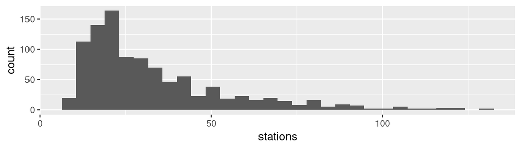

```r
p <- ggplot(quakes, aes(x = stations)) +
  geom_histogram()
p
```

- Specify the size of each bin in the histogram with the `binwidth` argument in `geom_histogram()`

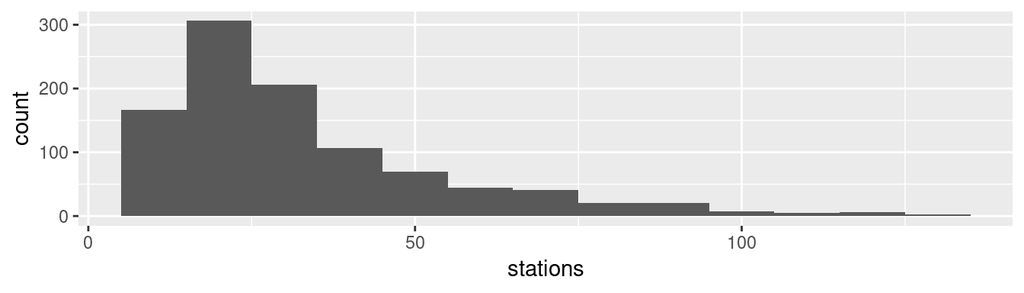

```r
p <- ggplot(quakes, aes(x = stations)) +
  geom_histogram(binwidth = 10)
p
```

- Notice that the default $y$-axis is `count`, i.e., the observation count of each bin
- This can be changed by specifying the `aes()` mapping of `y`
- For example, to generate a density histogram such that the points of each bin integrates to 1, set `aes(y=..density..)`
- For more options, see

```r
?geom_histogram
```

### Histogram with `aes(y=..density..)`

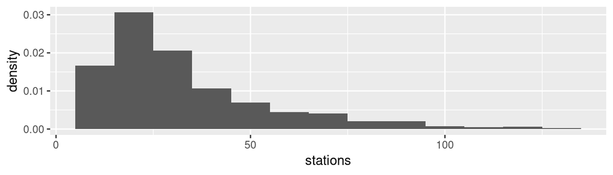

```r
p <- ggplot(quakes, aes(x = stations)) +
  geom_histogram(binwidth = 10, aes(y = ..density..))
p
```

## Exercise: single-variable plots

### Questions

1. Plot a density histogram of 1,000 random samples from a standard normal distribution using binwidth 0.5 (hint: use `rnorm()`)
2. Use `geom_density()` to plot the (smooth) density of the population (`pop`) variable from the `economics` data

### Solution 1

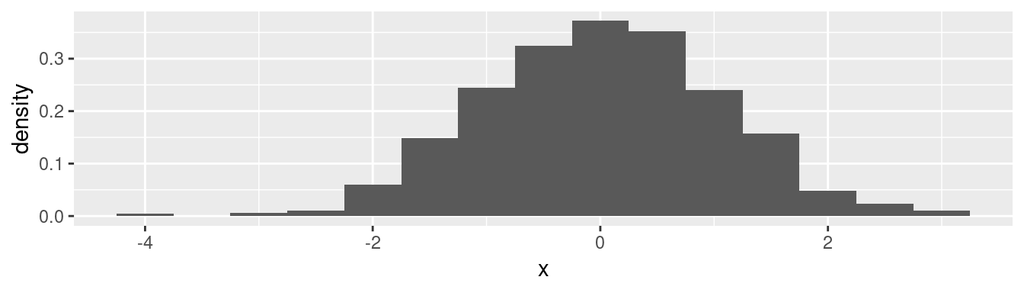

```r
X <- tibble(x = rnorm(1000))
p <- ggplot(data = X, aes(x = x)) +
  geom_histogram(binwidth = 0.5, aes(y = ..density..))
p
```

### Solution 2

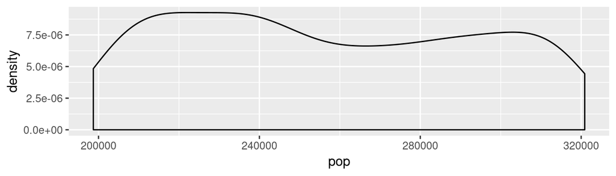

```r
p <- ggplot(data = economics, aes(x = pop)) +
  geom_density()
p
```

## 2+ variables

### Points with `geom_point()`

- Plot points on a 2D plane by specifying variables corresponding to the $x$ and $y$-axis, and adding the point geometry with `geom_point()`

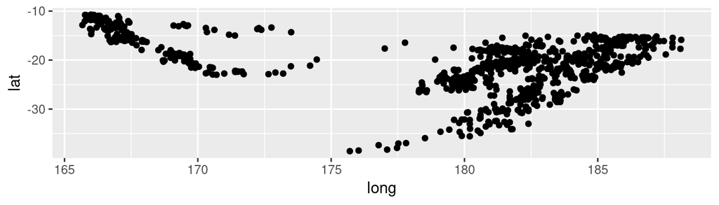

```r
p <- ggplot(quakes, aes(x = long, y = lat)) +
  geom_point()
p
```

- Popular `aes`thetics for `geom_point()` are
  - `alpha`: point visibility; 0 = invisible, 1 = opaque
  - `color`: color of the points (try `colors()` to see a list of some pre-defined colors)
  - `shape`: shape of the points (predefined, see next slide for reference)
  - `size`: size of the points
  - `fill`: color used to fill-in the points (only applies to certain shapes, i.e., shape numbers 21 to 25)

### Reference: Shapes

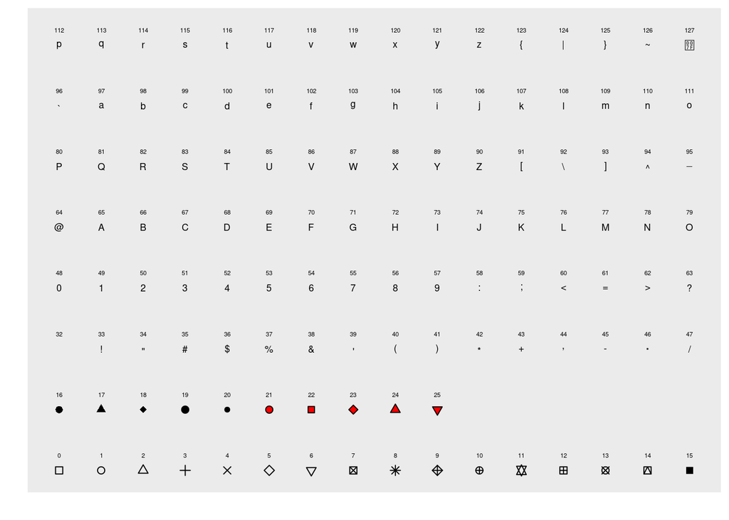

### Lines with `geom_line()`

- Similarly, plot lines on a 2D plane by specifying variables corresponding to the $x$ and $y$-axis, and adding the line geometry with `geom_line()`

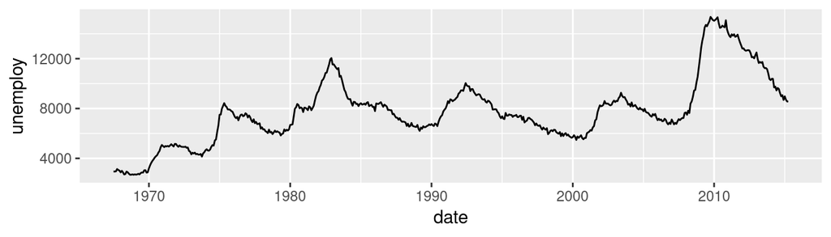

```r
p <- ggplot(economics, aes(x = date, y = unemploy)) +
  geom_line()
p
```

- Popular `aes`thetics for `geom_point()` are
  - `alpha`: line visibility; 0 = invisible, 1 = opaque
  - `color`: color of the lines
  - `linetype`: shape of lines (predefined, see next slide for reference)
  - `size`: size (thickness) of the lines

### Reference: Linetypes

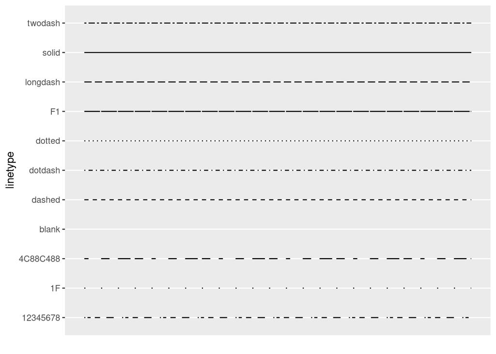

### A Note on `data` and `aes()` Arguments

- The `data` and `aes()` arguments, can be declared globally in the `ggplot()` function, or locally in each `geom`etry function
- Also, `aes`thetics can be either
  - mapped to a variable *globally*, i.e., in `ggplot(aes())`
  - mapped to a variable *locally*, i.e., in `geom_*(aes())`, or
  - defined explicitly for a local `geom_*()`, outside of `aes()`
- It’s critical to understand the difference between ‘mapping’ an aesthetic and ‘explicitly defining’ one as an argument

### Example: Global `aes()` mapping

```r
p <- ggplot(quakes, aes(x = long, y = lat, size = mag)) +
  geom_point(alpha = .3)
p
```

- the `data` and `aes`thetic mappings for `x`, `y`, and `size` are defined globally in `ggplot()`
- this means any `geom_*` added to this `ggplot` will have the specified `x`, `y`, and `size` `aes`thetic *mappings*, unless assigned otherwise within their own `geom_*()` function
- the `alpha` `aes`thetic for `geom_point`, on the other hand, is defined **explicitly** (i.e., it is **set** to 0.3, and not mapped to a variable)

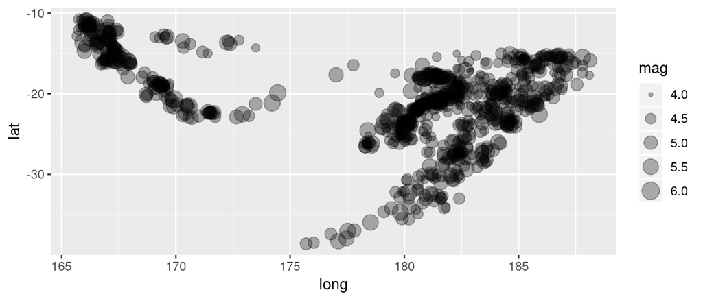

### Example: Local `aes()` mapping

```r
p <- ggplot(quakes, aes(x = long, y = lat)) +
  geom_point(alpha = .3, aes(size = mag)) +
  geom_point(size = 1, aes(color = stations))
p
```

- Here, the `data` and `aes`thetic mappings for `x` and `y` are defined globally in `ggplot()`
- But the `aes`thetic mapping/value for `size` is defined locally for each specific `geom_point()`
- The first `geom_point()` maps `size` to the `mag` variable, which means the size of the points will depend on the corresponding value of `mag`
- The second `geom_point()` explicitly assigns `size` to the fixed value 1, but maps the `color` `aes`thetic to the `stations` variable

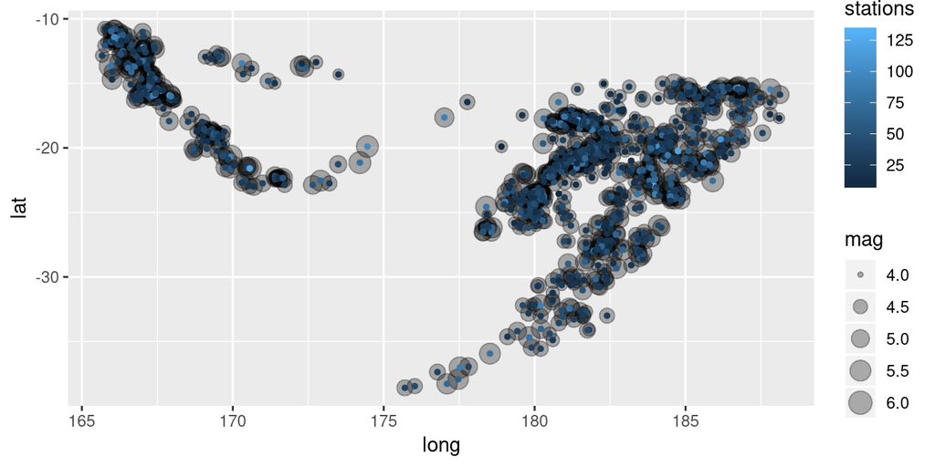

## Exercise: 2+ variables

### Questions

1. With the `mpg` dataset, generate a scatter plot with `hwy` on the $x$-axis and `cty` on the $y$-axis. Let the `color` represent to `class` and `size` represent `cyl`. Also set `alpha=.3`.

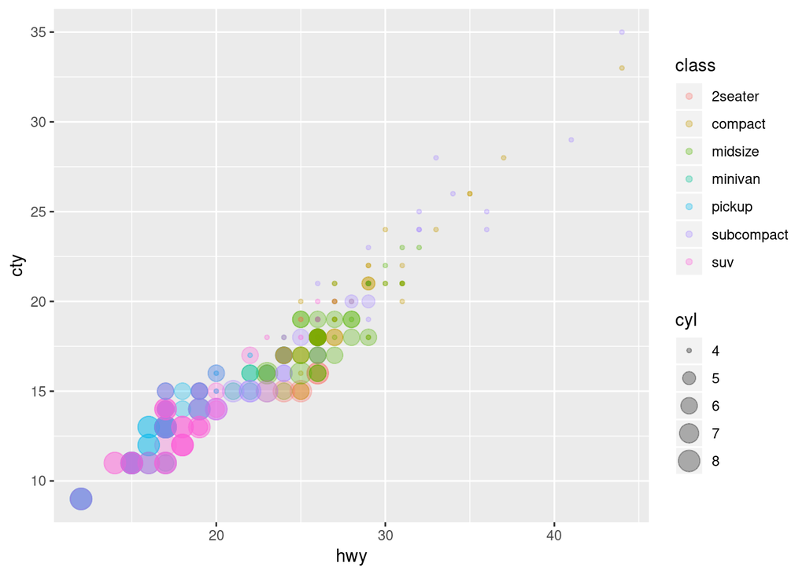

2. From the `quakes` plot on the previous slide, replace the blue colored points with *one big red star* (size=5, shape=8) showing which location had the largest magnitude (hint: you’ll need to crate another data frame consisting of the single observation you wish to plot)

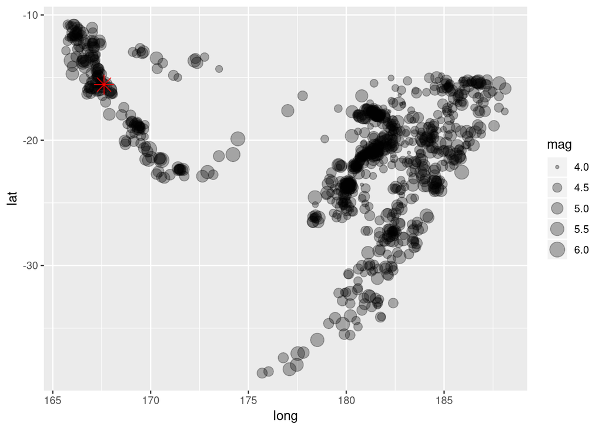

### Solution 1

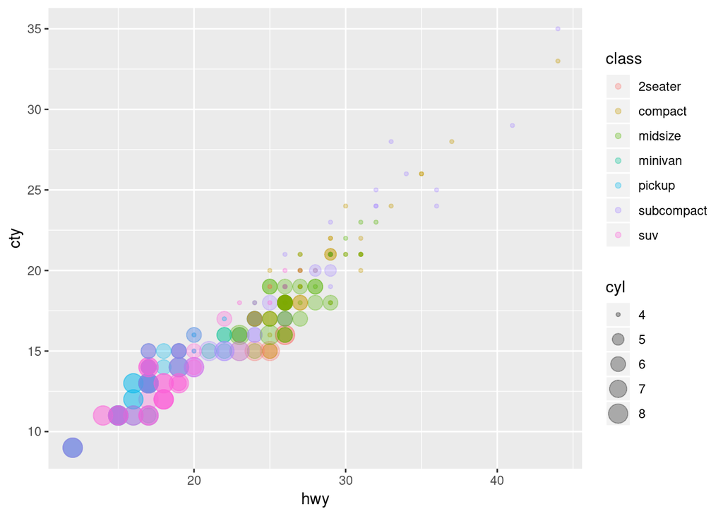

```r
p <- ggplot(mpg, aes(x = hwy, y = cty)) +
  geom_point(alpha = .3,
             aes(color = class, size = cyl))
p
```

### Solution 2

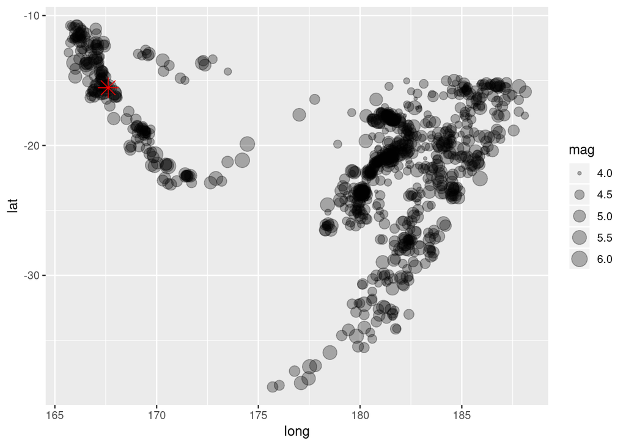

```r
# Find the largest magnitude observation
quakes_max_mag <- quakes %>%
  arrange(desc(mag)) %>%
  slice(1)

# Generate plot
p <- ggplot(quakes, aes(x = long, y = lat)) +
  geom_point(alpha = .3, aes(size = mag)) +
  geom_point(data = quakes_max_mag,
             size = 5,
             color = 'red',
             shape = 8)
p
```

## Labels, Scales, and More

### Labels

- Three major labels on a plot would be
  1. Plot title: use `ggtitle('title')`
  2. $x$-axis label: use `xlab('x label')`
  3. $y$-axis label; use `ylab('y label')`
- Or, to do all of the above in a single line, use

```r
labs(title='title', x='x label', y='y label')
```

- `paste()` or `sprintf()` functions could be useful if you want to construct labels from data

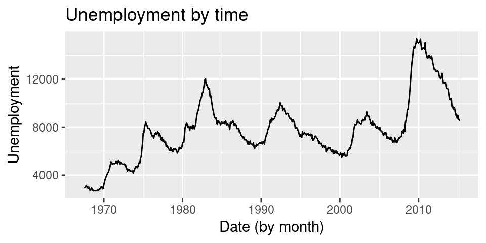

```r
p <- ggplot(economics, aes(x = date, y = unemploy)) +
  geom_line() +
  labs(title = 'Unemployment by time',
       x = 'Date (by month)',
       y = 'Unemployment')
p
```

### Scales

- The mapping between data and `aes`thetics is controled via **scales**
- The `scales` package provides many helpful functions when working with scales

```r
# Install, if you haven't already.
# Only need to do this once on a single machine.
install.packages('scales')
# load package into workspace
library('scales')
```

- The general syntax for setting scales is

```r
scales_{aes name}_{some option}(
    # name of legend/axis
    name = ...
    # range of data values to map
    limits = ...
    # what aesthetic values to use for the limits
    values = ...
    # where to mark legend/axis
    breaks = ...
    # what to label the marks (breaks)
    labels = ...
)
```

- Some scales have specific arguments/convenience functions
- Be sure to checkout the documentation!

### Axis Specific Scales

- There are scales specifically for controling the $x$/$y$-axes (examples are given for $x$, but can be used for $y$ by substituting $x$ for $y$)
  - `scale_x_log10()`: Plot $x$ on `log10` scale
  - `scale_x_reverse()`: Reverse the direction of the $x$ axis
  - `scale_x_sqrt()`: Plot $x$ on square root scale
  - `scale_x_date(labels=date_format("%m/%d"),` `breaks=date_breaks("2 weeks"))`: For axes in date format. See `?strptime` for label formats, and `scale_x_date` for more details
- For example, to plot `unemploy` against `date`, but mark the $x$ axis for every 15 years, we would write

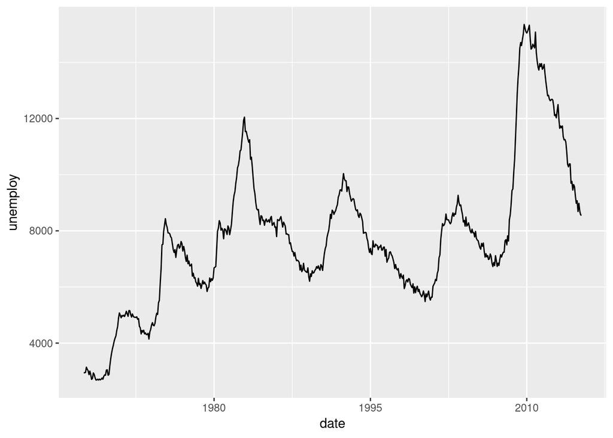

```r
p <- ggplot(economics, aes(x = date, y = unemploy)) +
  geom_line() +
  scale_x_date(labels = scales::date_format('%Y'),
               breaks = scales::date_breaks("15 years"))
p
```

### General Purpose Scales

- Scales for specific `aes`thetics can be controled with the following functions (where `*` should be replaced with the desired `aes`thetic, e.g., `color`, `shape`)
  - `scale_*_continuous()`: map continuous values to visual values
  - `scale_*_discrete()`: map discrete values to visual values
  - `scale_*_identity()`: map raw data to visual values (e.g., a data value of 1 equals shape #1)
  - `scale_*_manual()`: map discrete values to manually assigned visual values

### Scales: Example

- For example, with the `mpg` data, we wish to plot `hwy` against `cty`, with red points for `class=suv` and blue points otherwise

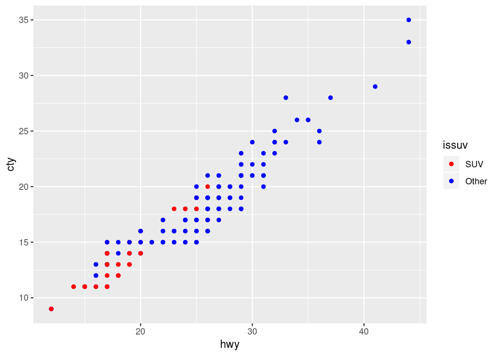

```r
# First, create a new column in the data indicating
# whether the entry has class suv or not
mpg_suv <- mpg %>%
  mutate(issuv = class == 'suv')
# Generate the plot with a manual color scale
p <- ggplot(mpg_suv, aes(x = hwy, y = cty)) +
  geom_point(aes(color = issuv)) +
  scale_color_manual(limits = c(FALSE, TRUE),
                     values = c('blue', 'red'),
                     breaks = c(TRUE, FALSE),
                     labels = c('SUV', 'Other'))
p
```

### Legends: Positions

- Changing legend position
- The `legend.justification` determines the ‘anchor point’ of the legend
- Takes a vector of two numbers between 0 and 1, where the first determines left(0)/right(1) and the second determines bottom(0)/top(1)
- For example, setting `legend.justification` to `c(0, 0)` would anchor the legend at left/bottom, while `c(1, 0)` would anchor the legend at right/bottom

```r
# specify either top/left/bottom/right, e.g.,
p <- p + theme(legend.position='top')
# or set x/y coordinates to position within plot
p <- p + theme(legend.position=c(0,1),
               legend.justification=c(0,0))
```

### Legends: Position Top Example

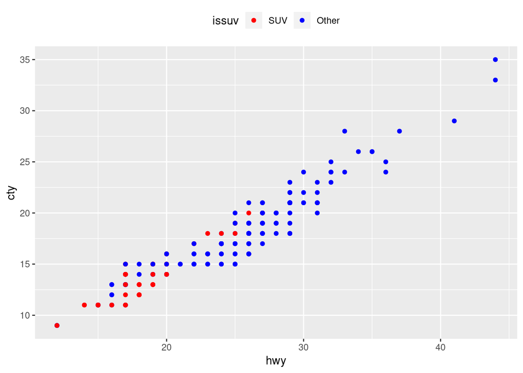

```r
p <- ggplot(mpg_suv, aes(x = hwy, y = cty)) +
  geom_point(aes(color = issuv)) +
  scale_color_manual(limits = c(FALSE, TRUE),
                     values = c('blue', 'red'),
                     breaks = c(TRUE, FALSE),
                     labels = c('SUV', 'Other')) +
  theme(legend.position = 'top')
p
```

### Legends: Position Example

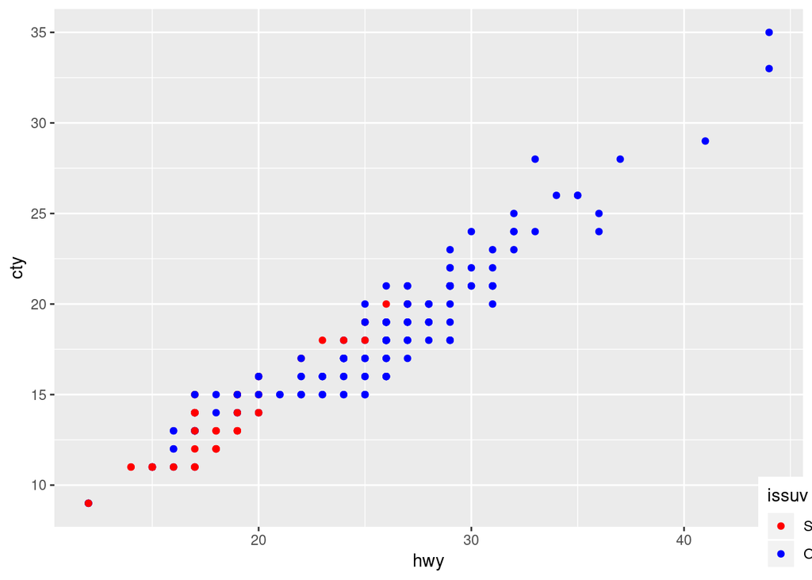

```r
p <- ggplot(mpg_suv, aes(x = hwy, y = cty)) +
  geom_point(aes(color = issuv)) +
  scale_color_manual(limits = c(FALSE, TRUE),
                     values = c('blue', 'red'),
                     breaks = c(TRUE, FALSE),
                     labels = c('SUV', 'Other')) +
  theme(legend.position = c(1, 0))
p
```

### Legends: Position Example

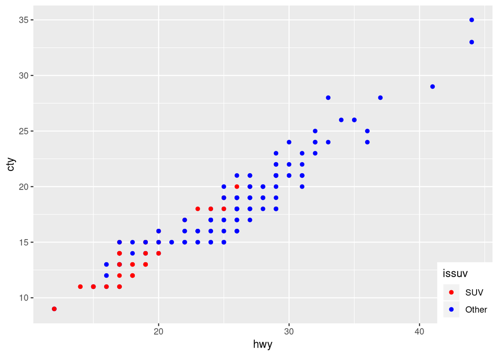

```r
p <- ggplot(mpg_suv, aes(x = hwy, y = cty)) +
  geom_point(aes(color = issuv)) +
  scale_color_manual(limits = c(FALSE, TRUE),
                     values = c('blue', 'red'),
                     breaks = c(TRUE, FALSE),
                     labels = c('SUV', 'Other')) +
  theme(legend.position = c(1, 0),
        legend.justification = c(1, 0))
p
```

### Legends: Guides

- `guides()` is used to set the legend type for specific `aes`thetics
- A common use-case is, for example, to hide legends by setting the `aes`thetic to `none` in `guides()`, e.g.,

```r
# Hide color legends
p <- p + guides(color = 'none')
```

### Legends: Scales

- As shown in the scales section, we can specify the title/breaks/labels for a legend, using the `scale_*_` of the corresponding `aes`thetic, e.g.,

```r
# To modify legend title/labels for a
# continuous variable applied to color aes()
p <- p + scale_color_continuous(
  name = 'legend title',
  breaks = c(1, 5),  # vector of points to label
  labels = c('low', 'high')  # corresponding labels
  )
```

### Legends (Example)

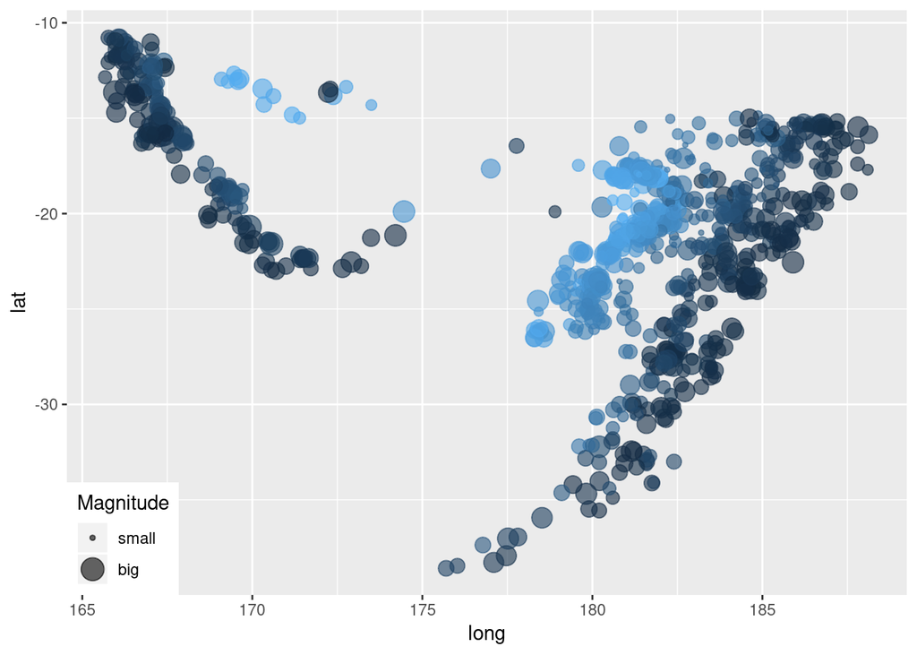

```r
p <- ggplot(quakes, aes(x = long, y = lat)) +
  geom_point(alpha = .6,
             aes(size = mag, color = depth)) +
  scale_size_continuous(name = 'Magnitude',
                        breaks = c(4, 6),
                        labels = c('small', 'big')) +
  theme(legend.position = c(0, 0),
        legend.justification = c(0, 0)) +
  guides(color = 'none')
p
```

### Legends: Remarks

- *Lots* of legend options (and more!) can be controlled via `theme()`
- Get familiar with the options in `?theme`

## Facets

- Facets let you divide a plot into subplots based on the values of a (discrete) variable
- The notation is

```r
# Divide into subplots of 2D grid
# using upto two variables
facet_grid( var.row ~ var.col)

# Wrap into a rectangular layout
# using a single variable
facet_wrap( ~ var, nrow = NULL, ncol = NULL)
```

- `var.row` is the name of the variable to use to divide the rows
- `var.col` is the name of the variable to use to divide the columns
- Substitute with ‘`.`’ to skip either row or column division
- Best demonstrated with examples …
- `facet_grid()` with one variable (columns)

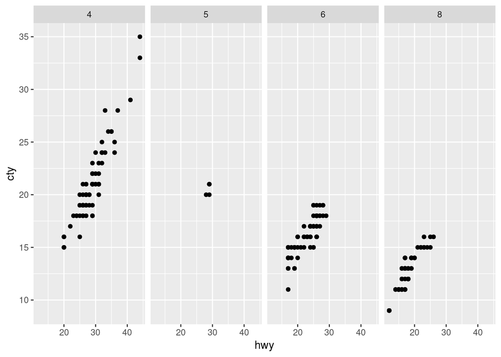

```r
p <- ggplot(mpg, aes(x = hwy, y = cty)) +
  geom_point() +
  facet_grid(. ~ cyl)
p
```

- `facet_grid()` with one variable (rows)

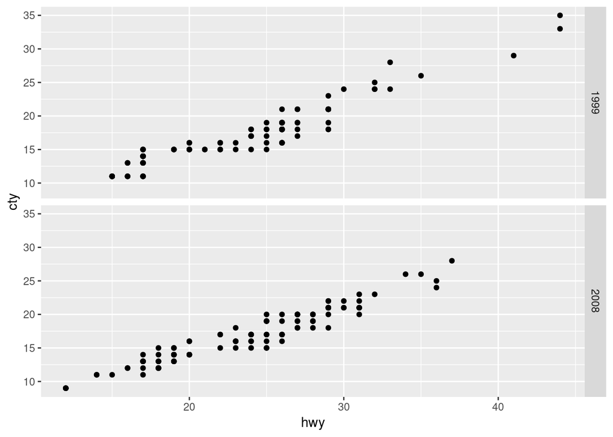

```r
p <- ggplot(mpg, aes(x = hwy, y = cty)) +
  geom_point() +
  facet_grid(year ~ .)
p
```

- `facet_grid()` with two variables

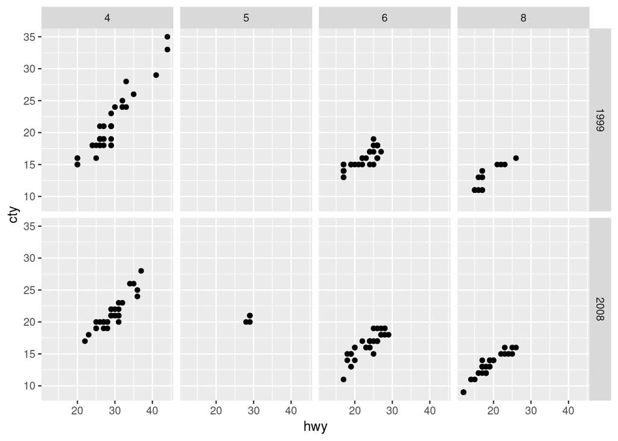

```r
p <- ggplot(mpg, aes(x = hwy, y = cty)) +
  geom_point() +
  facet_grid(year ~ cyl)
p
```

- `facet_wrap()`

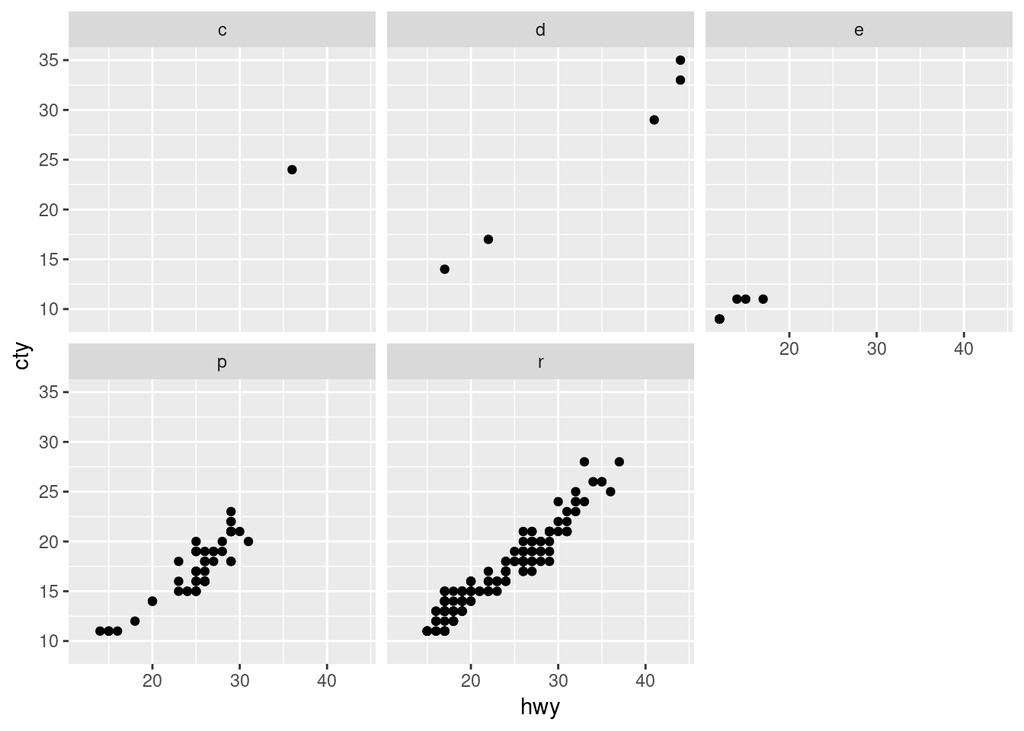

```r
p <- ggplot(mpg, aes(x = hwy, y = cty)) +
  geom_point() +
  facet_wrap(~ fl)
p
```

[^1]: There are also double arrows (`<<-`) that do something slightly different. We won’t talk about it, but if you’re interested, see [here](https://stackoverflow.com/questions/2628621/how-do-you-use-scoping-assignment-in-r)
[^2]: `Ctrl + Shift + M` will insert `%>%` in Rstudio